# QC Report: UHN Tsao Lung PDX XevaSet

2026-09-30

This document is a curation QC report for the UHN Tsao Lab lung cancer PDX `XevaSet`, built by the [Xevacurate Snakemake pipeline](https://github.com/BHKLAB-DataProcessing/Xevacurate_Snakemake_UHN_Lung).

## Load The Dataset

The curated object is stored as an `RDS` file in `expected_results/xevaset/`.

```
## XevaSet
## name: Tsao_Lung_2022
## Creation date: Mon Sep 14 18:32:52 2026
## Number of models: 1415
## Number of drugs: 35
## Moleculer dataset: RNASeq, mutation, cnv
```

The `XevaSet` bundles model metadata, drug metadata, tumor growth measurements, response summaries, and molecular profiles into one object.

| quantity | value |
| --- | --- |
| Model records | 1415 |
| Patients | 36 |
| Treatment-control batches | 131 |
| Treatments including control | 35 |
| Tumor volume measurements | 17021 |
| Molecular profile types | 3 |

## What Is Included?

| component | rows_or_items | fields_or_summary |
| --- | --- | --- |
| Model metadata | 1415 | model.id, drug, patient.id, sex, oncotree.code, primary.tumor.site, cancer.type.detailed, specimenID, primary.recurrence.metastasis, TNM.stage, engraftment.date, specimen.collection.site, modelID, sam… |
| Treatment metadata | 35 | drug.id, drugname.standardized, drug.alternativename, target, method, dose, dose.unit, treatment.type, drug.original, dose.original, frequency, is.single, CID, MolecularFormula, MolecularWeight, Conne… |
| Model-level response summaries | 1415 | model.id, slope, AUC, mRECIST, best.response, best.response.time, best.average.response, best.average.response.time |
| Batch-level response summaries | 131 | batch.name, slope.control, slope.treatment, angle, auc.control, auc.treatment, abc |
| Molecular profiles | 3 | RNASeq, mutation, cnv |
| Raw drug-screen files scanned | NA | see Raw Data Ingestion QC below |
| Raw records excluded (unmatched drug label) | NA | see Treatment Metadata below |

| model.id | drug.join.name | time | volume | dose | volume.normal |
| --- | --- | --- | --- | --- | --- |
| f1.PHLC402.TPX.crizotinib.P601 | crizotinib | 0 | 121.1911 | 50 | 0.0000000 |
| f1.PHLC402.TPX.crizotinib.P601 | crizotinib | 4 | 106.8797 | 50 | -0.1180895 |
| f1.PHLC402.TPX.crizotinib.P601 | crizotinib | 7 | 158.1836 | 50 | 0.3052408 |
| f1.PHLC402.TPX.crizotinib.P601 | crizotinib | 11 | 199.2673 | 50 | 0.6442402 |
| f1.PHLC402.TPX.crizotinib.P601 | crizotinib | 14 | 278.1199 | 50 | 1.2948874 |
| f1.PHLC402.TPX.crizotinib.P601 | crizotinib | 18 | 356.1285 | 50 | 1.9385696 |
| f1.PHLC402.TPX.crizotinib.P601 | crizotinib | 21 | 433.3961 | 50 | 2.5761383 |
| f1.PHLC402.TPX.crizotinib.P601 | crizotinib | 25 | 378.5005 | 50 | 2.1231713 |

## Raw Data Ingestion QC

Every raw drug-screen Excel file is scanned and parsed before curation. Files that fail to parse (e.g. an unexpected sheet layout) are logged rather than silently dropped.

| issue | files |
| --- | --- |
| file processed successfully | 85 |
| Could not find mouse number row | 15 |
| processed dataframe is empty | 6 |
| 1 | 1 |
| Could not find PHLC Sample number | 1 |

| file | issue |
| --- | --- |
| Master PI3K Series Excel File_140 PD P8 Dec 2013.xlsx | Could not find mouse number row |
| Master PHLC 77 Excel File_77_3_ P8 Aug 2014 Graphs.xlsx | Could not find mouse number row |
| Master PTEN-low Series Excel File_191 PD Pfizer Mar 2012 4 Arm.xlsx | Could not find mouse number row |
| Master EGFR Series Excel File (Excludes PHLC 12 and 77)_137 Perhaps.xlsx | Could not find PHLC Sample number |
| Master PI3K Series Excel File_152 PD P8 Nov 2013.xlsx | Could not find mouse number row |
| Master EGFR Series Excel File (Excludes PHLC 12 and 77)_164 PD P15 June 2013.xlsx | Could not find mouse number row |
| Master EGFR Series Excel File (Excludes PHLC 12 and 77)_164 PD P13 Feb 2013.xlsx | Could not find mouse number row |
| Master PI3K Series Excel File_267 *ID as 240* PD P8 Nov 2013.xlsx | Could not find mouse number row |
| Master PI3K Series Excel File_240 PD P7 Nov 2013 .xlsx | Could not find mouse number row |
| Master PI3K Series Excel File_77 PD P11 Nov 2013.xlsx | Could not find mouse number row |
| Master EGFR Series Excel File (Excludes PHLC 12 and 77)_164 PD P19 Jan 2014.xlsx | Could not find mouse number row |
| Master RET fusion Series Excel File_Sheet2.xlsx | Could not find mouse number row |
| Master RET fusion Series Excel File_410_Cabozantinib_Kelly.xlsx | processed dataframe is empty |
| Master PHLC 12 Excel File_12-186 from Cell line_Jan2014.xlsx | 1 |
| Master FGFR Series Excel File_267 P7 PD Sep 2013.xlsx | processed dataframe is empty |
| Master EGFR Series Excel File (Excludes PHLC 12 and 77)_164 P9 Jul 2015 Current.xlsx | processed dataframe is empty |
| Master PI3K Series Excel File_299 PD P7 Nov 2013 .xlsx | Could not find mouse number row |
| Master KRAS Series Excel File_151 P7 Sept 2015 Current.xlsx | processed dataframe is empty |
| Master PHLC 12 Excel File_12-12 failed exp_weight loss.xlsx | Could not find mouse number row |
| Master EGFR Series Excel File (Excludes PHLC 12 and 77)_192 P11 Aug 2014.xlsx | processed dataframe is empty |
| Master CDK4 Series Excel File_228 P6 PD Feb 2015.xlsx | Could not find mouse number row |
| Master PI3K Series Excel File_152_0_ PD P7 Sep 2013.xlsx | Could not find mouse number row |
| Master PHLC 12 Excel File_12-186_Cell Line_Jul2013_donor.xlsx | processed dataframe is empty |

## Model Metadata

Each row in the model metadata represents one drug-response experiment arm (one mouse/passage under one treatment). `parental.model.id` links related arms back to the same engrafted tumor line.

| model.id | drug | patient.id | sex | oncotree.code | primary.tumor.site | cancer.type.detailed | specimenID | primary.recurrence.metastasis | TNM.stage | engraftment.date | specimen.collection.site | modelID | sample.class | passage | host.strain.name | host.strain.nomenclature | engraftment.site | engraftment.type | engraftment.material | engraftment.material.status | pubmed.id | model.type | parental.model.id |
| --- | --- | --- | --- | --- | --- | --- | --- | --- | --- | --- | --- | --- | --- | --- | --- | --- | --- | --- | --- | --- | --- | --- | --- |
| f1.PHLC402.TPX.crizotinib.P601 | crizotinib | PHLC0402 | M | LUAD | Lung | Lung Adenocarcinoma | PHLC0402.TPT | primary | T4,N1,M0 | 2015-07-15 | Lung | PHLC0402.TPX | PX | 6 | NOD SCID | NOD.CB17-Prkdcscid/J | flank | heterotopic | tissue fragment | fresh | PMID: 27750381, PMID: 21081671, PMID: 27613526 | parental | PHLC0402.TPX |
| f1.PHLC402.TPX.crizotinib.P602 | crizotinib | PHLC0402 | M | LUAD | Lung | Lung Adenocarcinoma | PHLC0402.TPT | primary | T4,N1,M0 | 2015-07-15 | Lung | PHLC0402.TPX | PX | 6 | NOD SCID | NOD.CB17-Prkdcscid/J | flank | heterotopic | tissue fragment | fresh | PMID: 27750381, PMID: 21081671, PMID: 27613526 | parental | PHLC0402.TPX |
| f1.PHLC402.TPX.control.P603 | control | PHLC0402 | M | LUAD | Lung | Lung Adenocarcinoma | PHLC0402.TPT | primary | T4,N1,M0 | 2015-07-15 | Lung | PHLC0402.TPX | PX | 6 | NOD SCID | NOD.CB17-Prkdcscid/J | flank | heterotopic | tissue fragment | fresh | PMID: 27750381, PMID: 21081671, PMID: 27613526 | parental | PHLC0402.TPX |
| f1.PHLC402.TPX.crizotinib.P604 | crizotinib | PHLC0402 | M | LUAD | Lung | Lung Adenocarcinoma | PHLC0402.TPT | primary | T4,N1,M0 | 2015-07-15 | Lung | PHLC0402.TPX | PX | 6 | NOD SCID | NOD.CB17-Prkdcscid/J | flank | heterotopic | tissue fragment | fresh | PMID: 27750381, PMID: 21081671, PMID: 27613526 | parental | PHLC0402.TPX |
| f1.PHLC402.TPX.crizotinib.P605 | crizotinib | PHLC0402 | M | LUAD | Lung | Lung Adenocarcinoma | PHLC0402.TPT | primary | T4,N1,M0 | 2015-07-15 | Lung | PHLC0402.TPX | PX | 6 | NOD SCID | NOD.CB17-Prkdcscid/J | flank | heterotopic | tissue fragment | fresh | PMID: 27750381, PMID: 21081671, PMID: 27613526 | parental | PHLC0402.TPX |
| f1.PHLC402.TPX.crizotinib.P606 | crizotinib | PHLC0402 | M | LUAD | Lung | Lung Adenocarcinoma | PHLC0402.TPT | primary | T4,N1,M0 | 2015-07-15 | Lung | PHLC0402.TPX | PX | 6 | NOD SCID | NOD.CB17-Prkdcscid/J | flank | heterotopic | tissue fragment | fresh | PMID: 27750381, PMID: 21081671, PMID: 27613526 | parental | PHLC0402.TPX |
| f1.PHLC402.TPX.control.P607 | control | PHLC0402 | M | LUAD | Lung | Lung Adenocarcinoma | PHLC0402.TPT | primary | T4,N1,M0 | 2015-07-15 | Lung | PHLC0402.TPX | PX | 6 | NOD SCID | NOD.CB17-Prkdcscid/J | flank | heterotopic | tissue fragment | fresh | PMID: 27750381, PMID: 21081671, PMID: 27613526 | parental | PHLC0402.TPX |
| f1.PHLC402.TPX.control.P608 | control | PHLC0402 | M | LUAD | Lung | Lung Adenocarcinoma | PHLC0402.TPT | primary | T4,N1,M0 | 2015-07-15 | Lung | PHLC0402.TPX | PX | 6 | NOD SCID | NOD.CB17-Prkdcscid/J | flank | heterotopic | tissue fragment | fresh | PMID: 27750381, PMID: 21081671, PMID: 27613526 | parental | PHLC0402.TPX |

Key metadata columns include:

- `model.id`: unique drug-experiment model identifier (`f<batch>.<modelID>.<engraftment>.<drug>.<mouse>`).
- `patient.id`: patient-level identifier shared across related arms.
- `drug`: normalized treatment name (`control` for untreated arms).
- `oncotree.code` / `primary.tumor.site` / `cancer.type.detailed`: clinical annotation.
- `model.type` / `parental.model.id`: parental vs. derivative model lineage.

| field | models_annotated | models_missing | pct_annotated |
| --- | --- | --- | --- |
| sex | 1326 | 89 | 93.7 |
| oncotree.code | 1326 | 89 | 93.7 |
| primary.tumor.site | 1326 | 89 | 93.7 |
| cancer.type.detailed | 1326 | 89 | 93.7 |
| TNM.stage | 1314 | 101 | 92.9 |

## Treatment Metadata

Treatment metadata is annotated with PubChem cross-references where a compound identifier could be resolved.

| drug.id | drugname.standardized | target | dose | dose.unit | treatment.type | CID | MolecularFormula | InChIKey |
| --- | --- | --- | --- | --- | --- | --- | --- | --- |
| AZD4547 | AZD4547 | FGFR | 25 | mg/kg | regular | 51039095 | C26H33N5O3 | VRQMAABPASPXMW-HDICACEKSA-N |
| BGJ398 | BGJ398 | FGFR | 25 | mg/kg | regular | 53235510 | C26H31Cl2N7O3 | QADPYRIHXKWUSV-UHFFFAOYSA-N |
| BGJ398+crizotinib | BGJ398+crizotinib | FGFR+MET/ALK | 25+50 | mg/kg | regular | NA | NA | NA |
| BKM120 | BKM120 | PIKeCA | 50 | mg/kg | regular | 16654980 | C18H21F3N6O2 | CWHUFRVAEUJCEF-UHFFFAOYSA-N |
| PF384 | PF384 | PI3KCA | 10 | mg/kg | regular | NA | NA | NA |
| PF502 | PF502 |  |  | mg/kg | regular | NA | NA | NA |
| RG7388 | RG7388 | MDM2 | 80 | mg/kg | regular | 53358942 | C31H29Cl2F2N3O4 | TVTXCJFHQKSQQM-LJQIRTBHSA-N |
| RG7388-50 | RG7388 | MDM2 | 50 | mg/kg | variation | 53358942 | C31H29Cl2F2N3O4 | TVTXCJFHQKSQQM-LJQIRTBHSA-N |
| RO599 | RO599 |  |  | mg/kg | regular | NA | NA | NA |
| Vandetanib | Vandetanib |  |  | mg/kg | regular | 3081361 | C22H24BrFN4O2 | UHTHHESEBZOYNR-UHFFFAOYSA-N |
| afatinib | afatinib | EGFR | 25 | mg/kg | regular | 10184653 | C24H25ClFN5O3 | ULXXDDBFHOBEHA-CWDCEQMOSA-N |
| cetuximab | cetuximab | EGFR | 20 | mg/kg | regular | NA | NA | NA |
| cetuximab+RO599 | cetuximab+RO599 | EGFR+NA | 20+NA | mg/kg | regular | NA | NA | NA |
| cisplatin | cisplatin | DNA damage based chemo | 3 | mg/kg | regular | 5702198 | Cl2H6N2Pt | LXZZYRPGZAFOLE-UHFFFAOYSA-L |
| cisplatin+PF384 | cisplatin+PF384 | DNA damage based chemo+PI3KCA | 3+10 | mg/kg | regular | NA | NA | NA |
| cisplatin+vinorelbine | cisplatin+vinorelbine | DNA damage based chemo+taxol based chemo | 3+7 | mg/kg | regular | NA | NA | NA |
| control | control |  |  |  |  | NA | NA | NA |
| crizotinib | crizotinib | MET/ALK | 50 | mg/kg | regular | 11626560 | C21H22Cl2FN5O | KTEIFNKAUNYNJU-GFCCVEGCSA-N |
| dacomitinib | dacomitinib | EGFR | 3 | mg/kg | regular | 11511120 | C24H25ClFN5O2 | LVXJQMNHJWSHET-AATRIKPKSA-N |
| dacomitinib+PF502 | dacomitinib+PF502 | EGFR+NA | 3+NA | mg/kg | regular | NA | NA | NA |
| dacomitinib+valproic | dacomitinib+valproic | EGFR+HDAC | 3+NA | mg/kg | regular | NA | NA | NA |
| docetaxel | docetaxel | Taxane | 15 | mg/kg | regular | 148124 | C43H53NO14 | ZDZOTLJHXYCWBA-VCVYQWHSSA-N |
| docetaxel+sleumetinib | docetaxel+sleumetinib | Taxane+MEK | 15+25 | mg/kg | regular | NA | NA | NA |
| erlotinib | erlotinib | EGFR | 50 | mg/kg | regular | 176870 | C22H23N3O4 | AAKJLRGGTJKAMG-UHFFFAOYSA-N |
| erlotinib+RO599 | erlotinib+RO599 | EGFR+NA | 50+NA | mg/kg | regular | NA | NA | NA |
| erlotinib+crizotinib | erlotinib+crizotinib | EGFR+MET/ALK | 50+50 | mg/kg | regular | NA | NA | NA |
| gefitinib | gefitinib | EGFR | 100 | mg/kg | regular | 123631 | C22H24ClFN4O3 | XGALLCVXEZPNRQ-UHFFFAOYSA-N |
| gemcitabine | gemcitabine | antimetabolite | 100 | mg/kg | regular | 60750 | C9H11F2N3O4 | SDUQYLNIPVEERB-QPPQHZFASA-N |
| paclitaxel | paclitaxel | taxol based chemo | 10 | mg/kg | regular | 36314 | C47H51NO14 | RCINICONZNJXQF-MZXODVADSA-N |
| paclitaxel+PF502 | paclitaxel+PF502 | taxol based chemo+NA | 10+NA | mg/kg | regular | NA | NA | NA |
| palbociclib | palbociclib | CDK4 | 150 | mg/kg | regular | 5330286 | C24H29N7O2 | AHJRHEGDXFFMBM-UHFFFAOYSA-N |
| pemetrexed | pemetrexed | antifolate | 400 | mg/kg | regular | 135410875 | C20H21N5O6 | WBXPDJSOTKVWSJ-ZDUSSCGKSA-N |
| sleumetinib | sleumetinib | MEK | 25 | mg/kg | regular | NA | NA | NA |
| valproic | valproic | HDAC |  | mg/kg | regular | 3121 | C8H16O2 | NIJJYAXOARWZEE-UHFFFAOYSA-N |
| vinorelbine | vinorelbine | taxol based chemo | 7 | mg/kg | regular | 5311497 | C45H54N4O8 | GBABOYUKABKIAF-IELIFDKJSA-N |

Raw drug-screen rows whose treatment label could not be matched to a standardized drug are excluded during curation rather than guessed at.

| report | rows | source_files | models_affected |
| --- | --- | --- | --- |
| Excluded rows (unmatched treatment label) | 201 | 3 | 2 |

| file_name | drug | rows |
| --- | --- | --- |
| Master EGFR Series Excel File (Excludes PHLC 12 and 77)*164_1* P18 Sep 2013.xlsx | ?? | 55 |
| Master EGFR Series Excel File (Excludes PHLC 12 and 77)_164 P8 Mar 2011.xlsx | BIBW Rafeal Treatment | 46 |
| Master EGFR Series Excel File (Excludes PHLC 12 and 77)_164 P8 Mar 2011.xlsx | BIBW Yuhong Control | 26 |
| Master EGFR Series Excel File (Excludes PHLC 12 and 77)_164 P8 Mar 2011.xlsx | BIBW Yuhong Treat | 26 |
| Master EGFR Series Excel File (Excludes PHLC 12 and 77)_164 P8 Mar 2011.xlsx | Unknown Treatment | 26 |
| Master EGFR Series Excel File (Excludes PHLC 12 and 77)_137 BrDU P12 May 2015.xlsx | Naïve | 22 |

## Molecular Profiles

The molecular profiles are stored as `ExpressionSet` objects in the `XevaSet`. The matrix dimensions below are the feature-by-sample dimensions for each profile.

| profile | features | samples | feature_id_example | feature_metadata |
| --- | --- | --- | --- | --- |
| RNASeq | 19799 | 30 | A1BG | hgnc_symbol, ensembl_gene_id, entrezgene_id, gene_biotype, description |
| mutation | 19945 | 29 | A1BG | hgnc_symbol, ensembl_gene_id, entrezgene_id, gene_biotype, description |
| cnv | 22259 | 30 | A1BG | hgnc_symbol, ensembl_gene_id, entrezgene_id, gene_biotype, description |

Feature annotation (Ensembl gene ID, Entrez ID, gene biotype) is resolved via `biomaRt`. A small fraction of HGNC symbols fail to resolve to a current Ensembl gene ID, most often withdrawn or ambiguous symbols.

| profile | features | mapped_features | unmapped_features | mapped_fraction |
| --- | --- | --- | --- | --- |
| RNASeq | 19799 | 19136 | 663 | 0.9665 |
| mutation | 19945 | 17627 | 2318 | 0.8838 |
| cnv | 22259 | 18526 | 3733 | 0.8323 |

| mDataType | model_records_mapped |
| --- | --- |
| CNV | 1297 |
| RNASeq | 1297 |
| mutation | 1286 |

| patients | patients_with_rnaseq | patients_with_mutation | patients_with_cnv |
| --- | --- | --- | --- |
| 36 | 30 | 29 | 30 |

## Response Summaries

The pipeline computes model-level and batch-level response metrics using the `Xeva` package (slope, AUC, mRECIST, TGI-derived batch metrics).

| metric | available_models | pct_models |
| --- | --- | --- |
| slope | 1415 | 100.0 |
| AUC | 1415 | 100.0 |
| mRECIST | 1307 | 92.4 |
| best.response | 1307 | 92.4 |
| best.response.time | 1307 | 92.4 |
| best.average.response | 1307 | 92.4 |
| best.average.response.time | 1307 | 92.4 |

| metric | available_batches | pct_batches |
| --- | --- | --- |
| slope.control | 125 | 95.4 |
| slope.treatment | 131 | 100.0 |
| angle | 125 | 95.4 |
| auc.control | 125 | 95.4 |
| auc.treatment | 131 | 100.0 |
| abc | 125 | 95.4 |

### Response Metric Distributions

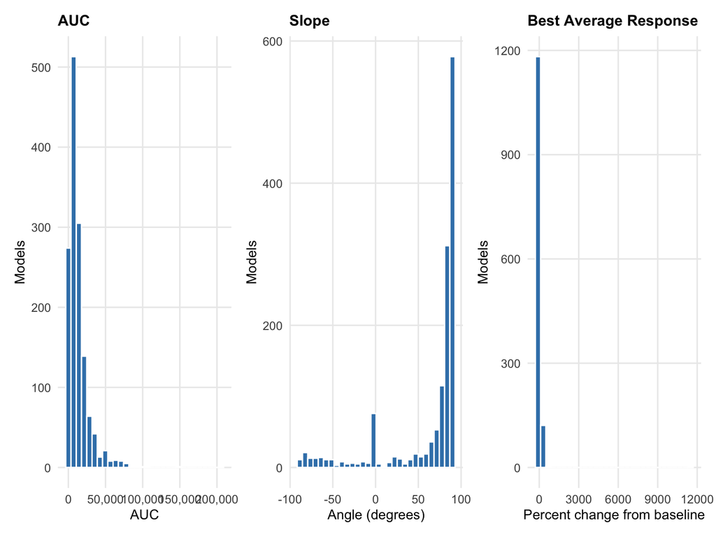

## mRECIST Summary

The `mRECIST` matrix summarizes response by treatment and patient.

```
## [1] 35 36
```

|  | PHLC0402 | PHLC0137 | PHLC0191 | PHLC0228 | PHLC0108 | PHLC0148 | PHLC0164 | PHLC0169 |
| --- | --- | --- | --- | --- | --- | --- | --- | --- |
| crizotinib | PD;PD;SD;PD;PD;PD;PD;PD;PD;PD;PD;PD | NA | NA | NA | NA | PR;CR;CR;CR;CR;CR;CR | NA | NA |
| control | PD;PD;PD;PD;PD;PD;PD;PD;PD;PD;PD | PD;PD;PD;PD;PD;PD;PD;PD;PD;PD;PD;PD;PD;SD;PD | PD;PD;PD;PD;PD;PD;PD;PD;PD;PD;PD;PD;PD;PD;PD;PD;PD;PD;PD;PD;PD;PD;PD;PD;PD;PD;PD;PD;PD;PD;PD;PD;PD;PD;PD;PD | PD;PD;PD;PD;PD | PD;PD;PD;PD | PD;PD;PD;PD;PD;PD;PD;SD;PD;PD;SD;PD;PD;PD;SD;PD;PD | PD;PD;PD;PD;PD;PD;PD;PD;PD;PD;SD;PD;SD;SD;PD;PD;PD;PD;PD;PD;PD;SD;PD;PD;PD;PD;PD;SD;SD;SD;SD;SD;SD;PD;PD;PD;PD;PD;PD;SD;PD;PD;PD;PD;SD;PD;PD;PD;PD;PD;PD;PD;PD;PD;PD;PD;PD;PD;PD;PD;PD;PD;PD;PD;PD;PD;PD… | PD;PD;PD;PD;PD;PD |
| palbociclib | NA | PD;SD;PD;PD;SD | PD;PD;PD;PD;PD | SD;PD;PD;PD;PD | NA | NA | NA | NA |
| dacomitinib | NA | CR;PR;PR;CR;PR;PR | PD;PD;PD;PD;PD;PD;PD;PD | NA | PD;PD;PD;PD;PD;PD | PD;PD;PD;PD;SD;PD | PD;PD;PD;PD;PD;PD;PD;PD;PD;PD;PD;PD;PD;PD;PD;PD;PD;PD;PD;SD;SD;SD;SD;SD;SD;SD;SD;PD;PD;PD;PD;PD;PD;SD;PD;PD;PD;PD;PD;PD;PD;SD;SD;SD;SD;SD;PD;PD;PD;PD;PD;PD;PD;SD;PD;PD;PD;PD;PD;PD;PD;PD;PD;SD;SD;PD;PD… | PD;PD;PD;PD;PD;PD |
| Vandetanib | NA | NA | NA | NA | PD;PD;PD;PD;PD;PD | NA | NA | NA |
| erlotinib | NA | PR;PR;PR;PR;PR;PR;PR;PR;PR;PR;PR;SD;SD;PR;SD;SD;PR;CR;PR;CR;PR;PR | NA | NA | NA | PD;SD;PD;PD;SD;SD | PD;PD;SD;SD;SD;PD;PD;PD;PD;PD;PD;PD | NA |
| erlotinib+crizotinib | NA | NA | NA | NA | NA | CR;CR;CR;CR;CR;CR;CR | NA | NA |
| cetuximab | NA | NA | NA | NA | NA | SD;SD;PD;SD;PD | PD;SD;SD;SD;PD;SD;SD;PD;PD;SD;PD;SD;PD | NA |

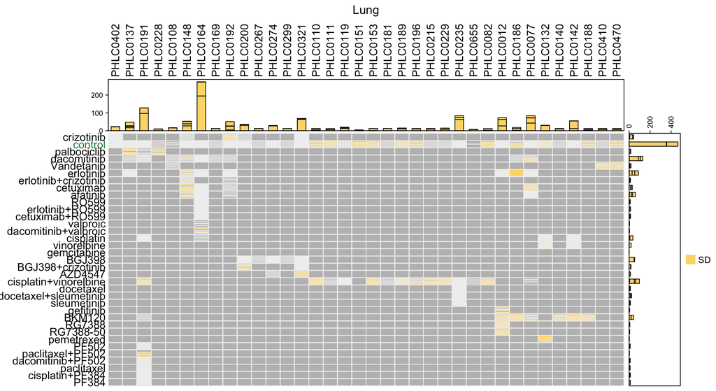

## Example Growth Curve

The batch-level plot pairs a treatment arm with its control arm for the same patient.

| field | value |
| --- | --- |
| Batch | f3.PHLC137.TPX.palbociclib |
| Control arms | f3.PHLC137.TPX.control.P802, f3.PHLC137.TPX.control.P803, f3.PHLC137.TPX.control.P806, f3.PHLC137.TPX.control.P808, f3.PHLC137.TPX.control.P810, f3.PHLC137.TPX.control.P812 |
| Treatment arms | f3.PHLC137.TPX.palbociclib.P801, f3.PHLC137.TPX.palbociclib.P805, f3.PHLC137.TPX.palbociclib.P807, f3.PHLC137.TPX.palbociclib.P809, f3.PHLC137.TPX.palbociclib.P811 |

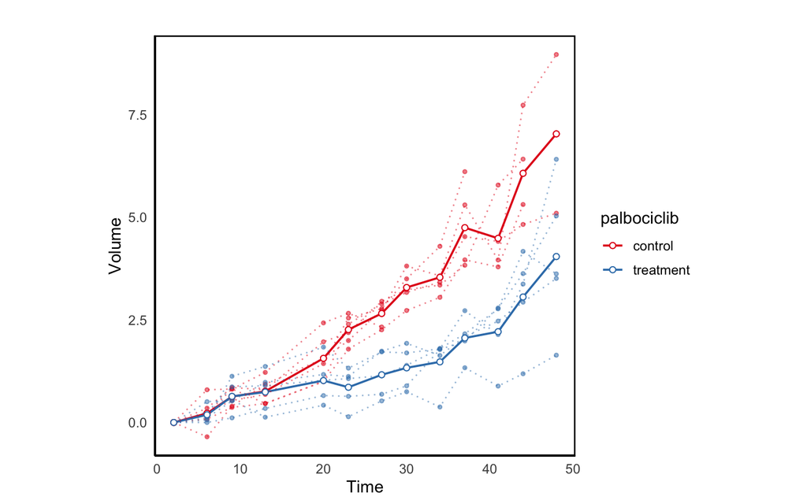

## Waterfall Plot

```
## [1] "dacomitinib"
```

### Model-level view

`waterfall()`’s own default is `group.by = "model.id"` (not `"patient.id"`, which is `summarizeResponse()`’s default elsewhere in this report), so each bar below is one individual model record, not one per patient. Patients contribute very unequal numbers of records for dacomitinib — see the per-patient count in the next panel — so a handful of heavily-replicated patients dominate this view.

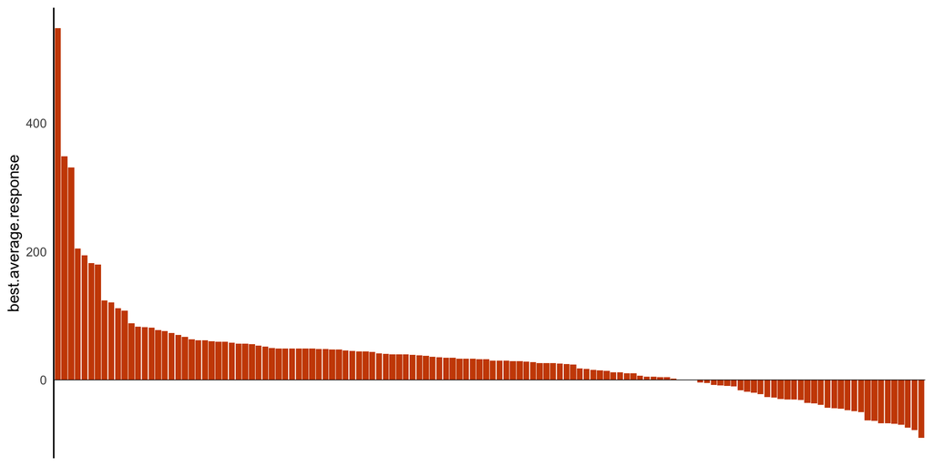

### Patient-level view

Collapsing to one bar per patient (`group.by = "patient.id"`) requires a `summary.stat` other than the default `";"` — cells with more than one record per patient would otherwise be joined into a non-numeric string and `waterfall()` would error. Using `"mean"` gives every patient equal visual weight regardless of how many replicate batches they contributed, at the cost of hiding within-patient spread.

| patient.id | records |
| --- | --- |
| PHLC0164 | 88 |
| PHLC0191 | 12 |
| PHLC0077 | 6 |
| PHLC0108 | 6 |
| PHLC0137 | 6 |
| PHLC0148 | 6 |
| PHLC0169 | 6 |
| PHLC0186 | 6 |
| PHLC0192 | 6 |

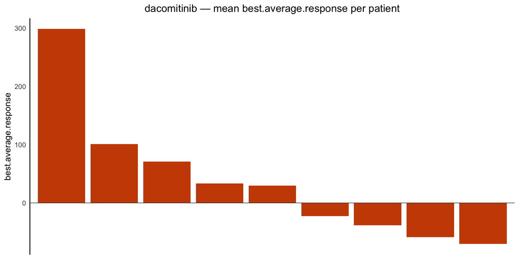